# Stat 371 Homework #9 solution. Due Sunday Nov. 8, 11:59 pm

Henry Mendoza Rivera, UW-Madison, Department of Statistics.

# 1 Problem 1

A sample of 54 males and 21 females was taken, and each person was asked to indicate which was their dominant hand. The data are as follows:

| Hand | Female | Male | Total |
| --- | --- | --- | --- |
| Left | 12 | 23 | 35 |
| Right | 9 | 31 | 40 |
| Total | 21 | 54 | 75 |

Does the proportion of Right-handed differ between females and males?. Test the hypothesis at the significance level $\alpha=0.05$. Follow the 5 Steps given in the lecture.

## 1.1 `Step 1:` State null and alternative hypotheses

1. `Claim`: “The proportion of left-handed persons differ between females and males.”
2. The random variables involved in the claim are:

$$\begin{align}
X_{FR}:&\; \textrm{The number of left-handed people in females population.}\\
X_{MR}:&\; \textrm{The number of left-handed people in the male population.}\\
X_{FR}-X_{MR}:&\; \textrm{The difference between number of left-handed in the female and male populations.}
\end{align}$$

3. The parameter of interest

$$\begin{align}
\textrm{Variable}\; X_{FR}:&\; \textrm{The parameter is}\; \pi_{FR} \\
\textrm{Variable}\; X_{MR}:&\; \textrm{The parameter is}\; \pi_{MR} \\
\textrm{Variable}\;X_{FR}-X_{MR}:&\; \textrm{the parameter is}\; \pi_{FR} - \pi_{\textrm{MR}}
\end{align}$$

$$\bbox[#ffcc99,20px,border:10px ligth red]
{
H_{0}: \pi_{FR} - \mu_{MR} = 0 \;\;\textrm{vs}\;\;H_{A}: \pi_{FR} - \pi_{MR} \ne 0
}$$

## 1.2 `Step 2:` Data exploration

| Hand | Female | Male | Total |
| --- | --- | --- | --- |
| Left | 12 | 23 | 35 |
| Right | `9` | `31` | 40 |
| Total | `21` | `54` | 75 |

The proportion in the sample of Right-handed female is $p_{FR}=\frac{x}{f}=0.429$ and the proportion of right-handed male is $p_{MR}=\frac{y}{m}=0.574$

[figure not shown]

```r
data<- c(Female=0.571, Male=0.426)
barplot(data,xlab = "Rigth-handed",col = c("blue3","green3"),ylab="Proportion",ylim = c(0,0.7))
text(1,.6,"0.571")
text(2,.5,"0.426")
```

## 1.3 `Step 3:` Check assumptions

- `Are the samples simple random samples?`

Yes.

- `Are the two populations independent?`

Yes. The data are not paired. That is, we have two different groups: female and male.

- Do the conditions for a binomial random variable met?

**Rigth-handed `female`**

1. The number of observations (females) $n_{F}=f$ is fixed.
2. The $n_{F}=f$ observations are independent.
3. Each observation (female) has two possible outcomes: success (left-handed) and failure (do not left-handed).
4. The probability of success on any trial is the same and unknown $\pi_{FR}$.
5. Then $X_{FR}$= Number of female who is left-handed has a `binomial distribution` with parameters $n_F=f$ and $\pi_{FR}$, abbreviated by

$$X_{FL}\sim Bin(n_{F}=f,\pi_{FR})$$

**Rigth-handed `male`**

1. The number of observations (males) $n_M=m$ is fixed.
2. The $n_{M}=54$ observations are independent.
3. Each observation (male) has two possible outcomes: success (left-handed) and failure (do not left-handed).
4. The probability of success on any trial is the same and unknown $\pi_{MR}$.
5. Then $X_{MR}$= Number of males who is right-handed has a `binomial distribution` with parameters $n_{M}=m$ and $\pi_{MR}$, abbreviated by

$$X_{MR}\sim Bin(n_M=m,\pi_{MR})$$

- `Are the sample sizes large enough?`

For testing purposes, what is required is that.

1. $n_{F}*\pi_{R}>5$
2. $n_{F}*(1 - \pi_{R})>5$
3. $n_{M}*\pi_{R}>5$
4. $n_{M}*(1 - \pi_{R})>5$

As `we do not know` the parameter $\pi_{R}$, we can use $P_{R}$ called `the common proportion` as an estimator of $\pi_{R}$.

With our data we have:

$p_{FR} = \frac{9}{21}=0.429$, $p_{MR} =\frac{31}{54} = 0.574$, and $p_{R} = \frac{9+31}{21+54} = 0.533$.

We can verify that all of the large sample size requirements are greater than 5, then this assumption is met, and `we are safe applying the Central Limit Theorem.`

# 2 Problem 2

An experiment was conducted to determine the concentration of a particular bacterium (*Pseudomonas syringae*) found adhering to rocks in river beds. Of particular interest was whether the number of bacteria was the same for rocks near the source of the river versus rocks near the outlet of the river. The experiment was conducted as follows. Six rivers in Iowa were randomly sampled. Then, for each river, the number of bacteria was measured for rocks at the source of the river and for rocks at the outlet of the river (and measured as number of bacteria per unit sample). The data are provided below with some summary statistics:

| River | 1 | 2 | 3 | 4 | 5 | 6 | Sample Mean | Sample Variance |
| --- | --- | --- | --- | --- | --- | --- | --- | --- |
| Source | 5600 | 2600 | 3260 | 4910 | 3750 | 1720 | 3640 | 2075800 |
| Outlet | 5480 | 2380 | 3300 | 4800 | 3680 | 1600 | 3540 | 2107520 |

## 2.1 A. Perform the relevant test to test the claim. Use $\alpha=0.01$. Follow the 5 Steps given in the lecture.

`Step 1:` State null and alternative hypotheses

$$\begin{align}
X_{source}:&\; \textrm{The average number of bacteria for rocks near the source of the river.}\\
X_{outlet}:&\; \textrm{The average number of bacteria for rocks near the outlet of the river}\\
X_{source}-X_{outlet}:&\; \textrm{The average difference for the number of bacteria between the rocks near the source and the outlet of the river.}
\end{align}$$

3. The parameter of interest

The parameters are

$$\begin{align}
\textrm{Variable}\; X_{source}:&\; \textrm{The parameter is}\; \mu_{source} \\
\textrm{Variable}\; X_{outlet}:&\; \textrm{The parameter is}\; \mu_{outlet} \\
\textrm{Variable}\;X_{source}-X_{outlet}:&\; \textrm{the parameter is}\; \mu_{source} - \mu_{\textrm{outlet}}
\end{align}$$

4. The claim in symbolic form is: $\mu_{source} \neq\mu_{outlet}$
5. The claim in symbolic form that must be opposite to the original claim is: $\mu_{source} = \mu_{outlet}$
6. The null hypothesis and alternative hypotheses

$$\bbox[#ffcc99,20px,border:10px ligth red]
{
H_{0}: \mu_{\textrm{source}} = \mu_{outlet} \;\;\textrm{vs}\;\;H_{A}: \mu_{source} \neq \mu_{outlet}
}$$

Or, equivalently:

$$\bbox[#ffcc99,20px,border:10px ligth red]
{
H_{0}: \mu_{\textrm{source}} -\mu_{outlet} = 0 \;\;\textrm{vs}\;\;H_{A}: \mu_{\textrm{source}} -\mu_{outlet}\neq 0
}$$

`Step 2:` Data exploration

- Read the data: This data is clearly paired, since we are taking two measurements on each individual.

```r
Source<-c(5600, 2600, 3260, 4910,  3750, 1720)
Outlet<-c(5480, 2380, 3300, 4800, 3680, 1600)
```

Usually, we use a boxplot to display data when comparing two samples. When we have a matched pairs situation however, this graph may not always be the best way to summarize the data. We need to use a graphing method that captures the pairing. An alternative is to use a scatter plot, where you plot one sample against the other. If we add a straight line with slope 1 and intercept 0, we can see more clearly how the pairs of observations match up with one another.

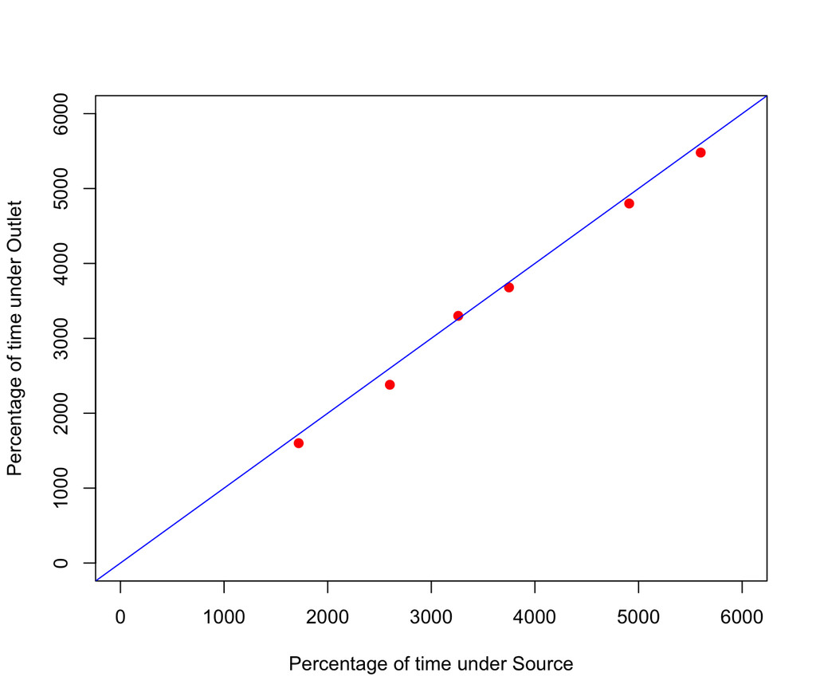

```r
plot(Source,Outlet,xlim=c(0,6000),ylim=c(0,6000),pch=19,
     col="red",xlab="Percentage of time under Source",
     ylab="Percentage of time under Outlet")

abline(a=0, b=1,col="blue")
```

Here looks like most of the points are close to the line. It could suggest that the means are equal.

- So, to do the paired $T$-test, the first step is to take the differences.

```r
diffs<-Source-Outlet
diffs
```

```
## [1] 120 220 -40 110  70 120
```

[output not shown]

## 2.2 Numerical Summary

```r
summary(diffs)
```

```
##    Min. 1st Qu.  Median    Mean 3rd Qu.    Max.
##     -40      80     115     100     120     220
```

```r
sd(diffs)
```

```
## [1] 84.61678
```

Table 1: Summary statistics of the differences in percentages under Outlet and Source conditions.

|  | n | Min | Max | Mean | SD | 1st Q | Median | 3rd Q |
| --- | --- | --- | --- | --- | --- | --- | --- | --- |
| diffs | 6 | -40 | 220 | 100 | 84.61678 | 80 | 115 | 120 |

## 2.3 Graphical summary

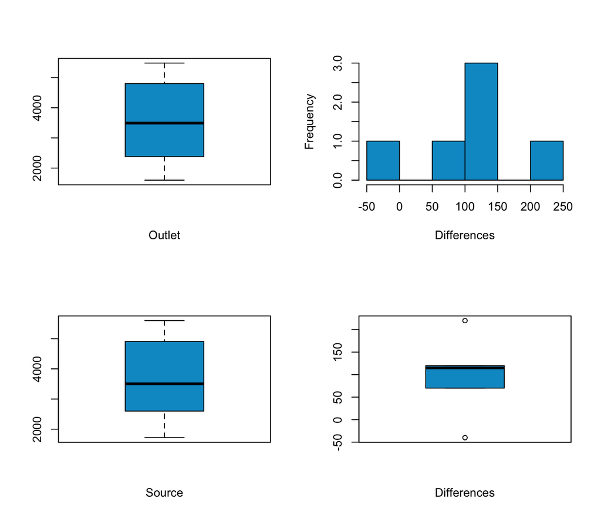

```r
par(mfrow=c(2,2))

boxplot(Outlet,col = "deepskyblue3",xlab="Outlet")
hist(diffs,col = "deepskyblue3",xlab="Differences",main = "")
boxplot(Source,col = "deepskyblue3",xlab="Source")
boxplot(diffs,col = "deepskyblue3",xlab="Differences")
```

The outlet and Source data are slightly symmetric but the distribution of the differences is not symmetric and there is some outliers.

`Step 3.` Check assumptions

- Is the match pairs a simple random sample?

Yes.

- Are the two group of data dependent?

Yes. Since we have paired data. It was taken for each river two measures.

- Do the pairs of values have differences that are from a normal distribution?.

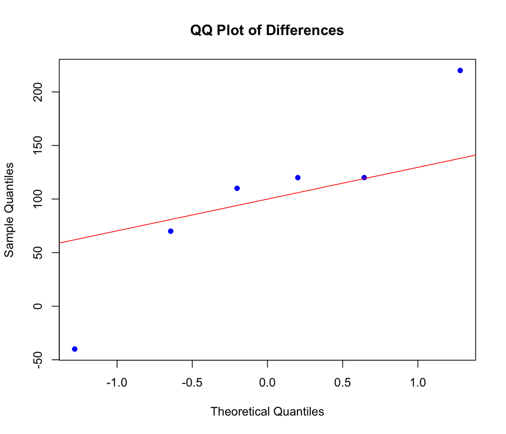

```r
#qq of diffs#

qqnorm(diffs, main = "QQ Plot of Differences", col="blue",pch=16)
qqline(diffs, col="red")
```

This looks not quite straight, so we cannot safely assume normality.

1. Notice that the no-normality can be caused by the presence of oultiers.
2. Outliers tend to increase the estimate of standard error, thus decreasing the calculated t statistic and `reduce the probability of rejecting the null hypothesis` and increase the probability of not rejecting the null hypothesis.
3. We are going to test the hypothesis using the t-test anyway just to check what we mention in 2. Then, we will use the bootstrap t-test that do not require normality.

Note

`Step 4.` Perform the appropriated test statistic and make the decision

If we let $\mu_{d}$ be the true mean difference, then we want to test:

$$\bbox[#ffcc99,20px,border:10px ligth red]
{
H_{0}: \mu_{d} = 0 \;\;\textrm{vs}\;\;H_{A}: \mu_d\ne 0
}$$

### 2.3.1 Test Statistics

```r
diffs<- Source - Outlet
tobs=(mean(diffs)-0)/(sd(diffs)/sqrt(6))
tobs
```

```
## [1] 2.894804
```

To take the decision about the null hypothesis, we can use either of the following methods:

#### 2.3.1.1 Method 1: Rejection region

Since $\alpha = 0.01$. We put half of $\alpha/2=0.005$ in the tails on either side of the distribution.

The rejection region is defined by:

$$\bbox[#ffcc99,20px,border:10px ligth red]
{
\textrm{Reject}\;\; H_0\;\; \textrm{if:}\; T \le t_{(5,0.005)} \;\textrm{or} \; T \geq t_{(5,0.995)}
}$$

Where $t_{(5,0.005)}$ and $t_{(5,0.995)}$ are called the `critical values`.

```r
critical.lower=qt(0.005, 5)
critical.lower
```

```
## [1] -4.032143
```

```r
critical.upper=qt(0.995, 5)
critical.upper
```

```
## [1] 4.032143
```

Then, the `rejection region` is

$$\bbox[#ffcc99,20px,border:10px ligth red]
{
\textrm{Reject}\;\; H_0\;\; \textrm{if:}\; T \le -4.03 \;\textrm{or} \; T \geq 4.03
}$$

Since our observed test statistic, t.obs=2.89 do fall into the no rejection region, `we do not have evidence to reject the null hypothesis`. This is what we expected for the presence of the outliers.

#### 2.3.1.2 Method 2: Method of p-value

```r
p.value=2*pt(tobs,df=5,lower.tail = FALSE)
p.value
```

```
## [1] 0.03399589
```

#### 2.3.1.3 Method 2: Method of Confidence Interval

The observed 99% confidence interval
$$\bbox[#ffcc99,20px,border:10px ligth red]
{
\Big(\bar{d}−t_{5,0.995}*\frac{sd(d)}{\sqrt{n}}\;,\;\bar{d}+t_{5,0.995}*\frac{sd(d)}{\sqrt{n}}\Big)
}$$

```r
ci<-mean(diffs)+c(-1,1)*qt(0.995,5)*sd(diffs)/sqrt(6)
ci
```

```
## [1] -39.289 239.289
```

Because the confidence interval in part contains zero, we would fail to reject the null hypothesis at level $0.01$.

We can obtain all results above at once using the function `t.test()` in R.

```r
t.test(Source,Outlet, paired=TRUE, alternative="two.sided",conf.level=0.99)
```

```
##
##  Paired t-test
##
## data:  Source and Outlet
## t = 2.8948, df = 5, p-value = 0.034
## alternative hypothesis: true difference in means is not equal to 0
## 99 percent confidence interval:
##  -39.289 239.289
## sample estimates:
## mean of the differences
##                     100
```

## 2.4 Boostrap Method

```r
# Bootstrap Function
bootstrap = function(x, n.boot) {
  n = length(x)
  x.bar <- mean(x)
  t.hat <- numeric(n.boot) # create vector of length n.boot zeros
  for(i in 1:n.boot) {
    x.star <- sample(x, size=n, replace=TRUE)
    x.bar.star <- mean(x.star)
    s.star <- sd(x.star)
    t.hat[i] <- (x.bar.star - x.bar) / (s.star / sqrt(n))
}
  return(t.hat)
}


# tobs

tdiff.obs<-(mean(diffs)-0)/(sd(diffs)/sqrt(length(diffs)))
tdiff.obs
```

```
## [1] 2.894804
```

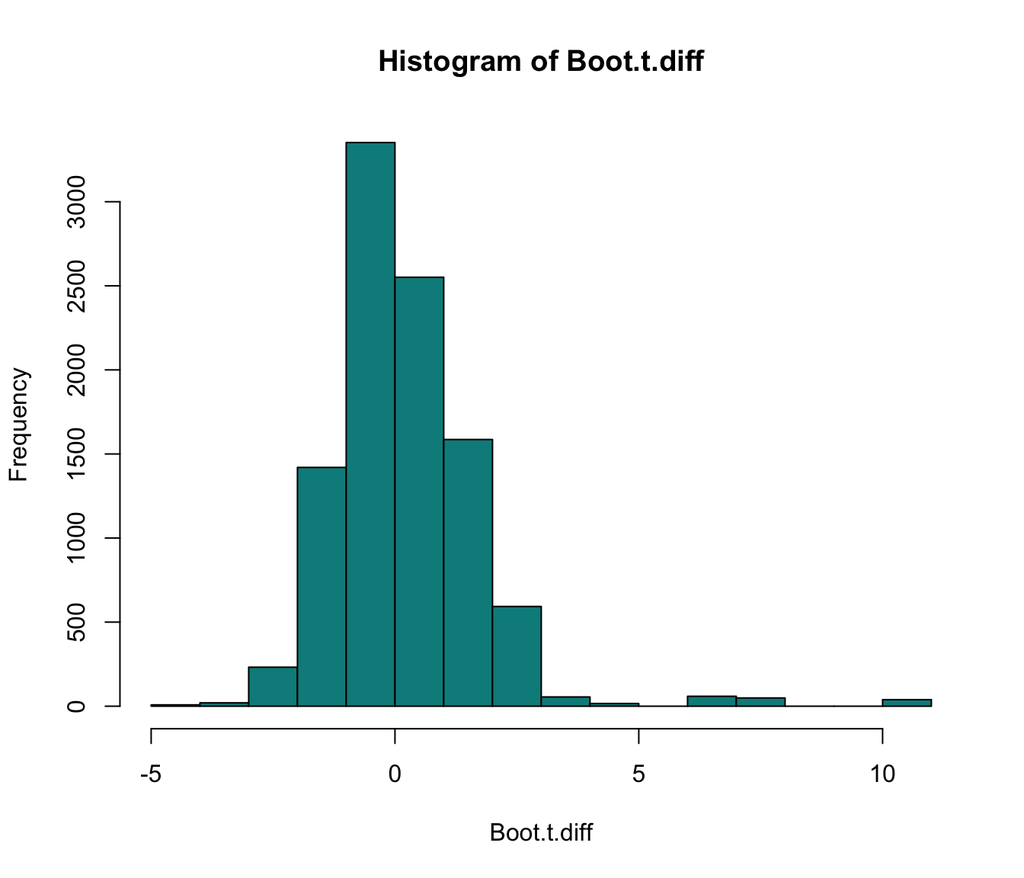

```r
set.seed(1)
B=10000
Boot.t.diff<-bootstrap(diffs, B)
hist(Boot.t.diff,col = "darkcyan")
```

```r
(m.above<-sum(Boot.t.diff >= abs(tdiff.obs)))  #290
```

```
## [1] 290
```

```r
(m.below<-sum(Boot.t.diff <= -abs(tdiff.obs)))  #28
```

```
## [1] 28
```

```r
(p.value<-2*min(m.below,m.above)/B)  #0.0056
```

```
## [1] 0.0056
```

p-value= $0.0056$. This test is giving us evidence in favor of the alternative. We reject the null hypothesis.

The bootstrap tests give us enough evidence at the 1% level the number of bacteria for rocks and outlet near of the river are different.

# 3 B. Wilcoxon Signed Rank

The scientists then wonder if actually they should perform a Wilcoxon Signed Rank instead because of the heavy tails of the sample data and the small sample size. Test the hypothesis at the significance level $\alpha=0.05$.

```r
wilcox.test(Source, Outlet, paired=TRUE,conf.level = 0.95)
```

```
##
##  Wilcoxon signed rank test with continuity correction
##
## data:  Source and Outlet
## V = 20, p-value = 0.05848
## alternative hypothesis: true location shift is not equal to 0
```

We do not reject the null hypothesis at 5% significant level.

Now, we will test the hypothesis at 1% to compare with the Bootstrap t-test.

```r
wilcox.test(Source, Outlet, paired=TRUE,conf.level = 0.99)
```

```
##
##  Wilcoxon signed rank test with continuity correction
##
## data:  Source and Outlet
## V = 20, p-value = 0.05848
## alternative hypothesis: true location shift is not equal to 0
```

We also, do not reject the null hypothesis at 1% significant level.

## 3.1 C. Compare your findings in A and B.

The paired t-test assumed normality. It is not a recommended test in this situation. The Bootstrap t-test do not assume normality but is affected by the presence of outliers.

The Wilcoxon Signed Rank test is the recommended approach. It does not reject the null hypothesis.